# Conditional Dependence Modeling - 1D

Seoncheol Park

03/12/2019

이 문서에서는 R `texmex` 패키지로 conditional dependence modeling에 대해 다룬다.

```r
library(texmex)
```

```r
library(gridExtra)
library(ggplot2)
palette(c("black","purple","cyan","orange"))
set.seed(20130618)
```

# 자료

## Rain data

여기서 쓰는 자료는 Coles (2011) 에서 나오는 `rain` 자료다.

```r
########################################
#Data
########################################
head(rain)
```

```
## [1] 0.0 2.3 1.3 6.9 4.6 0.0
```

```r
summary(rain)
```

```
##    Min. 1st Qu.  Median    Mean 3rd Qu.    Max.
##   0.000   0.000   0.500   3.476   4.300  86.600
```

```r
length(rain)
```

```
## [1] 17531
```

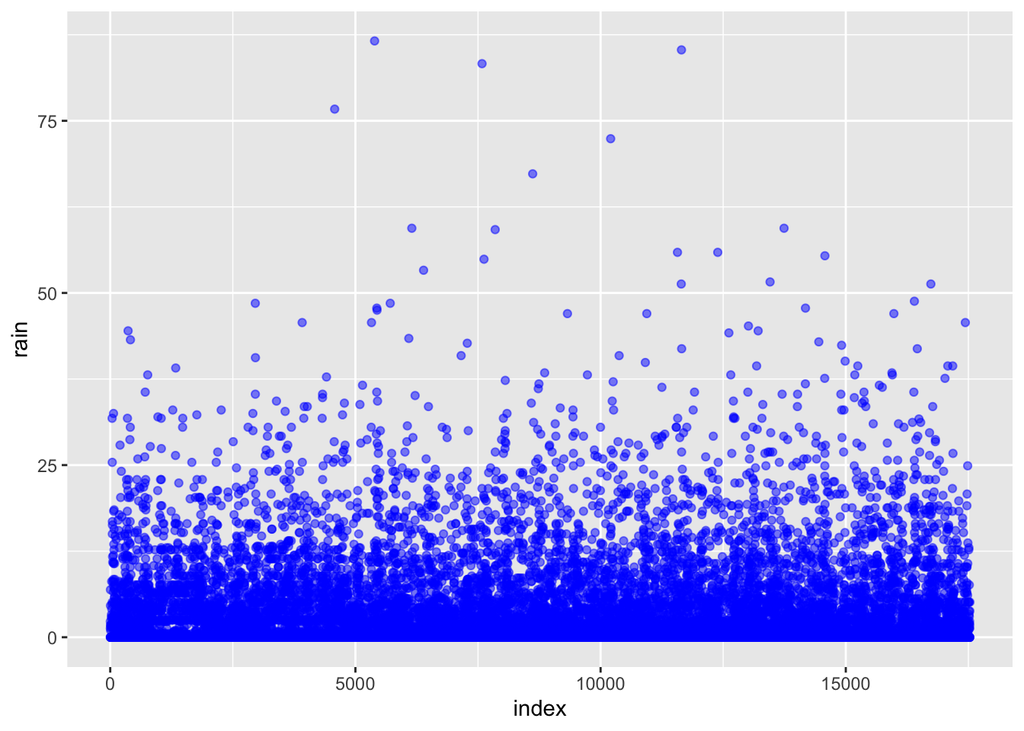

```r
d1 <- ggplot(data=data.frame(rain=rain,index=1:length(rain)), aes(index,rain)) +
  geom_point(alpha=0.5,col=4)
d1
```

## 겨울 air pollution data

```r
########################################
#Winter air pollution data
########################################
head(winter)
```

```
##   O3 NO2  NO SO2 PM10
## 1 27  50 112  13   34
## 2 27  51 126  13   29
## 3 15  43  90  21   33
## 4  9  71 470  44  101
## 5 20  51 167  48   30
## 6  8  50 211  16   44
```

```r
summary(winter,digits=3)
```

```
##        O3            NO2              NO           SO2           PM10
##  Min.   : 1.0   Min.   : 19.0   Min.   : 10   Min.   :  1   Min.   :  7.0
##  1st Qu.:10.0   1st Qu.: 36.8   1st Qu.: 64   1st Qu.:  8   1st Qu.: 29.0
##  Median :22.0   Median : 43.0   Median :112   Median : 15   Median : 40.0
##  Mean   :20.1   Mean   : 44.2   Mean   :135   Mean   : 21   Mean   : 48.4
##  3rd Qu.:29.0   3rd Qu.: 51.0   3rd Qu.:166   3rd Qu.: 26   3rd Qu.: 60.0
##  Max.   :44.0   Max.   :104.0   Max.   :568   Max.   :200   Max.   :177.0
```

```r
dim(winter)
```

```
## [1] 532   5
```

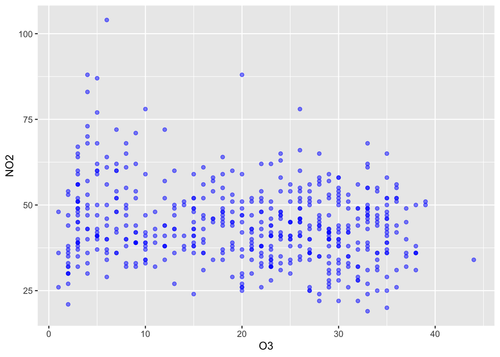

```r
d2 <- ggplot(winter,aes(O3,NO2)) + geom_point(alpha=0.5,col=4)
d2
```

여기서는 `NO2`, `O3` 자료에 대해 초점을 맞춰 분석해보기로 한다.

## Portpirie data

```r
########################################
#Portpirie data
########################################
head(portpirie)
```

```
##   Year SeaLevel
## 1 1923     4.03
## 2 1924     3.83
## 3 1925     3.65
## 4 1926     3.88
## 5 1927     4.01
## 6 1928     4.08
```

```r
summary(portpirie)
```

```
##       Year         SeaLevel
##  Min.   :1923   Min.   :3.570
##  1st Qu.:1939   1st Qu.:3.830
##  Median :1955   Median :3.960
##  Mean   :1955   Mean   :3.981
##  3rd Qu.:1971   3rd Qu.:4.110
##  Max.   :1987   Max.   :4.690
```

```r
dim(portpirie)
```

```
## [1] 65  2
```

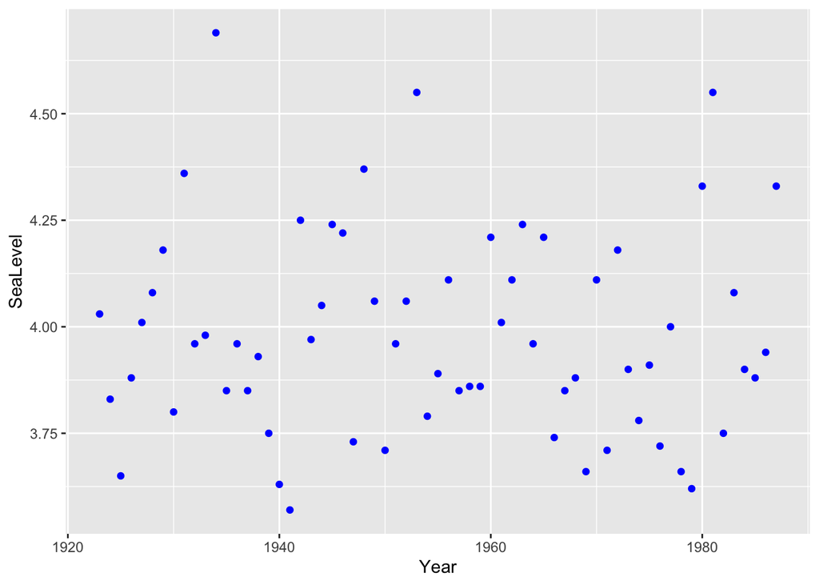

```r
d3 <- ggplot(portpirie,aes(Year,SeaLevel)) + geom_point(col=4)
d3
```

# Generalized Pareto Distribution (GPD) Models

## Extreme value modeling and asymptotic motivation for the GPD

$\text{GPD}(\sigma,\xi)$의 CDF는 다음과 같다.

$$\begin{equation}
F_{>u}(x) = 1 - \Bigg\{ 1+ \xi \Bigg( \frac{x-u}{\sigma} \Bigg) \Bigg\}^{-\frac{1}{\xi}}, \qquad{\text{ for } x>u,}
\end{equation}$$
where

- $u$ is the threshold for fitting and
- $\sigma>0$: scale parameter
- $\xi \in \mathbb{R}$: shape parameter.

GPD는 관찰값이 $u$를 초과할 때의 조건부 분포가 된다.

GPD값이 갖는 range 또한 모수 값에 따라 달라진다.

- $\xi <0$일 때에는 $u<x\leq u-\frac{\sigma}{\xi}$
- $\xi\geq 0$일 때에는 $u<x<\infty$
- $\xi=0$일 때에는 GPD는 Exponential distn과 정확히 같게 된다.

Extreme value theory는 threshold excesses를 적당히 normalisation 시키면 그것의 limiting distn은 반드시 generalized Pareto family에 속하게 된다고 말해준다.

## Parameterization

GPD는 보통 scale parameter $\sigma$, shape parameter $\xi$로 모델링한다 `texmex` 패키지에서는 $\sigma$대신 $\phi=\log \sigma$로 모델링한다. 그 이유는

- $\phi$로 모델링할 때 수치 알고리즘이 더 잘 작동하고
- 로그변환을 시키면 $\sigma>0$과 같은 제약 조건을 크게 신경 쓰지 않아도 알아서 잘 모델링하며
- 모수에 prior distn을 줄 때에는 Gaussian 분포로 모델링하는 것이 편하며 이 때 $\sigma$보다 $\phi$가 Gaussian에 가깝게 행동할 것이다.

## Threshold selection

GPD 모델링 시 가장 신경써야 하는 부분 중 하나가 threshold를 어떻게 잡을 것이냐는 부분이다. 이에 대해 `texmex` 패키지는 **mean residual life (MRL) plot**과 **threshold stability plot**을 그릴 수 있게 제공한다.

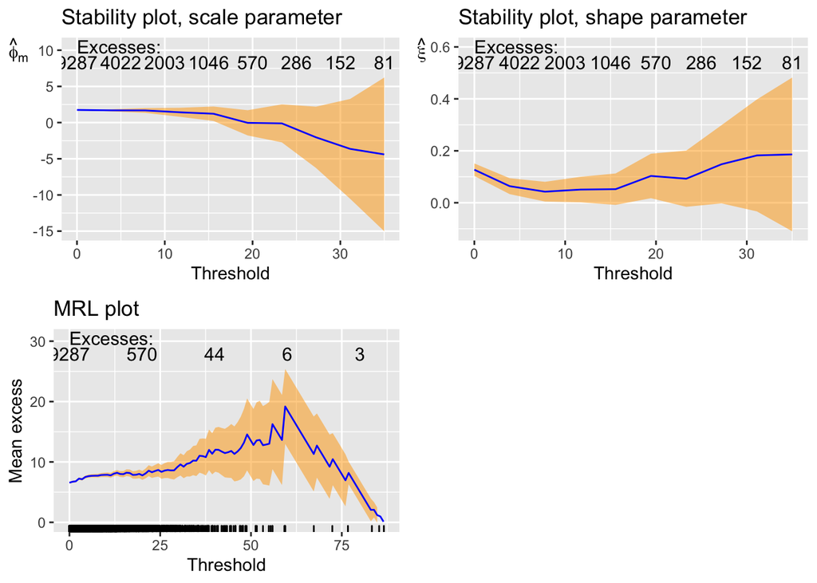

```r
########################################
#Generalized Pareto distribution models
########################################
########################################
#Threshold selection
########################################
grfRain <- gpdRangeFit(rain,umax=35)
mrlRain <- mrl(rain)

g1 <- ggplot(grfRain)
g2 <- ggplot(mrlRain)

grid.arrange(g1[[1]] + ggtitle("Stability plot, scale parameter"),
             g1[[2]] + ggtitle("Stability plot, shape parameter"),
             g2 + ggtitle("MRL plot"),ncol=2)
```

위의 두 그림은 $\log \hat{\sigma}$, $\hat{\xi}$에 대해 threshold stability plot, 밑의 그림은 MRL 그림을 출력한 것이다. threshold stability plot에서는 threshold가 20정도 될 때 까지 두 값 모두 stable함을 알 수 있다. 밑의 MRL plot은 threshold가 60 근처일 때까지 선형성을 띄고 있는데, heavy tail, positive shape parameter를 갖고 있다는 증거다.

여기서는 그림을 보고 $97$-th percentile을 candidate threshold로 정했다고 한다.

```r
quantile(rain, 0.97)
```

```
##  97%
## 20.6
```

여기서 한 가지 짚고 넘어갈 점은 GPD 이론은 어딘가에 threhold가 존재해 GPD 분포롤 잘 추정할 수 있다는 것을 알려주지만, 그 threshold가 꼭 커야 한다고 말하지는 않는다. 예를 들어, 자료가 지수분포에서 왔다고 하면 ($\xi=0$) threshold는 equal to the minimum data point가 될 것이다. 또한 자료의 갯수가 적을 경우에도 threshold 추정에 문제가 생길 수 있다.

## texmex package에서의 GPD fitting

`texmex` 패키지에서는 `family=gpd`로 놓은 `evm` 함수로 추정할 수 있다. `rain` 자료를 예로 추정을 하면 다음과 같다.

```r
rain.fit <- evm(rain,th=20)
rain.fit
```

```
## Call: evm(y = rain, th = 20)
## Family:       GPD
##
## Model fit by maximum likelihood.
##
## Convergence:     TRUE
## Threshold:       20
## Rate of excess:      0.03251
##
##   Log. lik   AIC       DIC
##   -1740.834  3485.667  3485.736
##
##
## Coefficients:
##        Value    SE
## phi:   1.92214  0.06348
## xi:    0.13224  0.04802
```

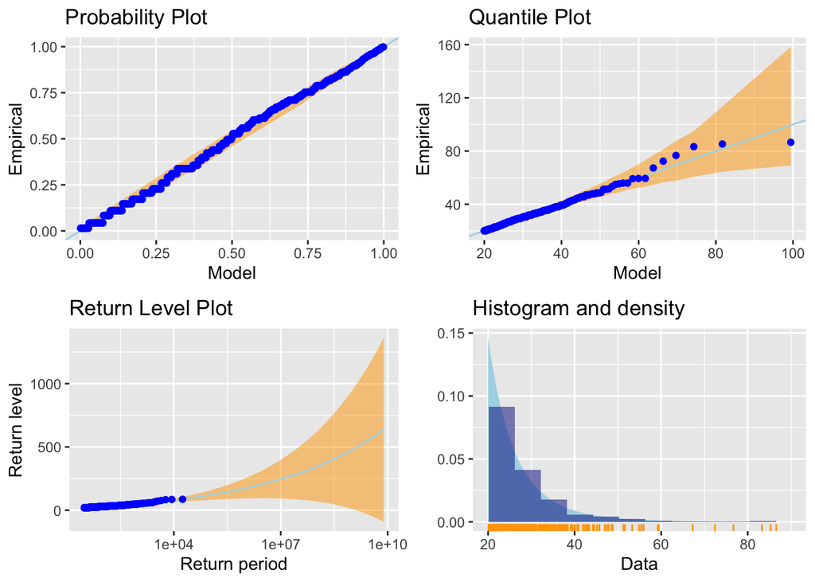

```r
ggplot(rain.fit)
```

결과에서 $\hat{\xi}>0$이므로 heavy-tail이라고 할 수 있다. `ggplot`을 이용해 진단을 할 수 있다. P-P, Q-Q plot에서 음영이 칠해져 있는 부분은 95% tolerance intervals, based on 1000 simulation datasetsdlek. Return level plot에서 음영이 칠해진 부분은 95% pointwise confidence intervals로 normal approximation으로 구한 것을 칠한 것이다.

진단 그림으로 보았을 때 데이터와 모델이 잘 부합함을 알 수 있다. 한편 trehold를 많이 낮추면 어떻게 될까?

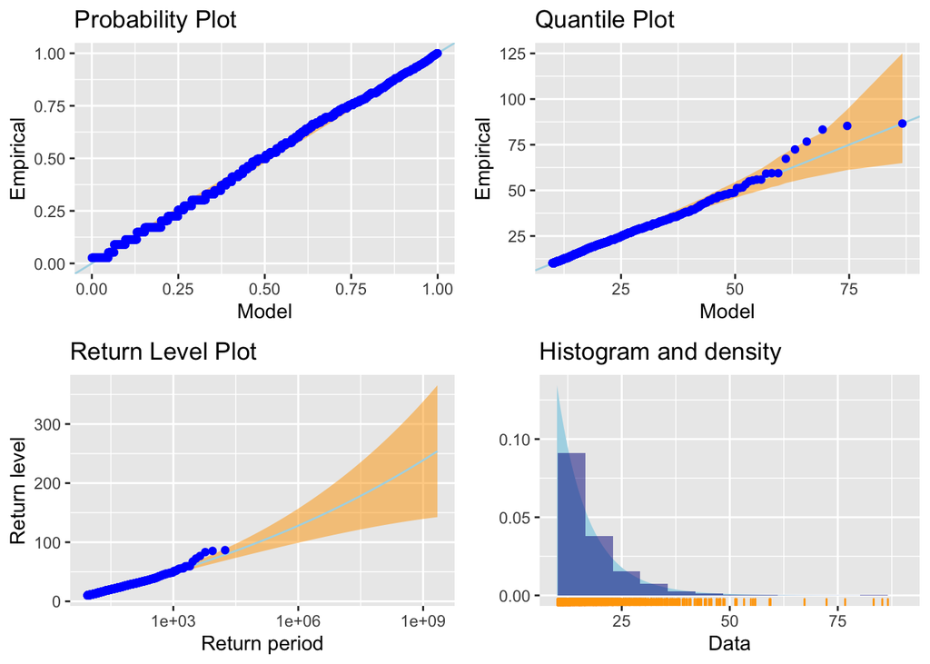

```r
ggplot(evm(rain,th=10))
```

## Maximum penalized likelihood estimation

Sample size가 작을 때 GPD log=likelihood 함수는 종종 flat하게 되어 수렴하지 않을 수 있게 된다. 이런 경우에는 penalized method를 쓰는 것이 한 가지 해결책이 될 수도 있다. Experience suggests that the main problems may be overcome by putting fairly modest penalties on $\xi$.

따라서, 그냥 log-likelihood $l(\phi, \xi | X)$를 최대화하는 대신
$$l(\phi, \xi | X)$-\lambda \xi^{2}$$
과 같은 penalized version을 최대화시키는 것을 생각해 볼 수 있다.

### $\lambda$의 선택

위 식에서, exponential을 취하면
$$L(\phi,\xi|X)e^{-\frac{\xi^2}{2\theta^2}}$$
로 변한다. 이 때 $\theta = \sqrt{\frac{1}{2\lambda}}$가 된다. $e^{-\frac{\xi^2}{2\theta^2}}$ 부분은 중심이 0인 정규분포에 비례하므로, mle를 Bayesian 추정 할 수 있게 된다. (and corresponds to maximum a posteriori estimation)

GPD의 경우에는 $\xi=-1$일 때에는 distn이 uniform과, $\xi=0$일 때에는 exponential, 그리고 $\xi=1$일 때에는 heavy-tail 및 기대값이 $\infty$가 된다. 많은 응용 사례에서 $\xi=-1$, $\xi=1$인 경우는 implausible(받아들이기 힘든)이므로, 보통 $\xi$가 fairly close to 0을 기대한다. 그래서 prior distn을 0에 중심이 있고 standard deviation을 $\theta=\frac{1}{2}$로 둔 Gaussian으로 두고 모델링하게 된다.

Coles, Stuart. 2011. *An Introduction to Statistical Modeling of Extreme Values*. Springer London. https://www.ebook.de/de/product/13423684/stuart_coles_an_introduction_to_statistical_modeling_of_extreme_values.html.